# LeMonde #1053: Coin Denominations

[Website](http://www.statsblogs.com/2018/06/20/le-monde-puzzle-1053/)

# Overview

1. If coins come in units of 1, x, and y, what is the optimal value of (x,y) that minimises the number of coins representing an arbitrary price between 1 and 149?
2. If the number of units is now four, what is the optimal choice?

```r
library(tidyverse)
```

# Problem 1

From the original author:

```
The first question is fairly easy to code
```

```r
coinz <- function(x,y){
  z=(1:149)
  if (y<x){xx=x;x=y;y=xx}
  ny=z%/%y
  nx=(z%%y)%/%x
  no=z-ny*y-nx*x
  return(max(no+nx+ny))
}
```

```
and returns M=12 as the maximal number of coins, corresponding to x=4       and y=22. And a price tag of 129.
```

While the statement from the author is true (based on the algorithm he coded here), there are a large number of combinations that generate the same *minimal* number of coins. In addition, the price that requires 12 coins (129) is not unique. In fact, the patterns make for rather interesting plots.

Having said all that, the author notes down below that the algorithm above is not optimal. There are ways to use fewer coins than using the remainder division above. (See the cos() function near the end).

- Why is this not optimal?

I can easily demonstrate that it is not optimal. Consider a case of attempting to reach a price of 8 using coins of values 1, 4, and 5. Using the algorithm above would yield:

```
1 coin = 5
0 coins = 4
3 coins = 1
4 coins total
```

Versus using 2 of the coins with a value of 4. In general, how do we ensure we are getting a minimal set? More of that at the end of this notebook.

Going back to the algorithm used above:

I think I have seen this problem before where the additional constraint was to minimize the value of x+y. This results in a unique coin combination but still has two purchase prices with the same number of coins. In the case of x=4, y=22 the prices are 129 and 147.

There are 39 combinations of coin values that result in the minimum coin count of 12. Some of these coin combinations have a single maximum, 2 maxima, and 3 maxima. These combinations are enumerated below. First, all results. Second, the best worst-case performance. Finally, the number of maxima for each of the best results.

```r
coinz2 <- function(x,y){
  z=(1:149)
  if (y<x){xx=x;x=y;y=xx}
  ny=z%/%y
  nx=(z%%y)%/%x
  no=z-ny*y-nx*x
  return(data.frame(z=z,count=no+nx+ny))
}
m=c()
for (x in 2:148) {
  for (y in x:149) {
    s=coinz2(x,y)
    m=rbind(m,c(x,y,max(s$count)))
  }
}
m=data.frame(m)
names(m)=c("x","y","worst")
m
```

| x | y | worst |
| --- | --- | --- |
| 2 | 2 | 75 |
| 2 | 3 | 50 |
| 2 | 4 | 38 |
| 2 | 5 | 31 |
| 2 | 6 | 27 |
| 2 | 7 | 23 |
| 2 | 8 | 21 |
| 2 | 9 | 19 |
| 2 | 10 | 19 |
| 2 | 11 | 17 |

[output cut: 990 more lines]

```r
mbest <- m[m$worst==min(m$worst),]
mbest
```

|  | x | y | worst |
| --- | --- | --- | --- |
| 314 | 4 | 22 | 12 |
| 315 | 4 | 23 | 12 |
| 318 | 4 | 26 | 12 |
| 319 | 4 | 27 | 12 |
| 323 | 4 | 31 | 12 |
| 459 | 5 | 22 | 12 |
| 460 | 5 | 23 | 12 |
| 461 | 5 | 24 | 12 |
| 463 | 5 | 26 | 12 |
| 464 | 5 | 27 | 12 |

[output cut: 29 more lines]

Even for a given combination of coins, there may be multiple different purchase totals that result in the maximum number of coins.

For example, with x=4, y=22 we have:

```r
s=coinz2(4,22)
which(s$count==max(s$count))
```

```
[1] 129 147
```

Both of these totals will require 12 coins. The number of coins versus price is shown below:

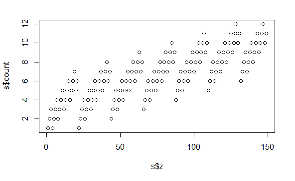

```r
plot(s$z,s$count)
```

We can determine the number of maxima for each coin configuration as shown below:

```r
nmax=c()
for (i in 1:nrow(mbest)) {
  x=mbest[i,]$x
  y=mbest[i,]$y
  s=coinz2(x,y)
  nmax=c(nmax,length(which(s$count==max(s$count))))
}
mbest=cbind(mbest,nmax)
mbest %>% group_by(nmax) %>% summarize(n=n())
```

| nmax | n |
| --- | --- |
| 1 | 11 |
| 2 | 23 |
| 3 | 5 |

Combinations with 3 maxima:

```r
mbest[mbest$nmax==3,]
```

|  | x | y | worst | nmax |
| --- | --- | --- | --- | --- |
| 323 | 4 | 31 | 12 | 3 |
| 476 | 5 | 39 | 12 | 3 |
| 604 | 6 | 23 | 12 | 3 |
| 750 | 7 | 26 | 12 | 3 |
| 751 | 7 | 27 | 12 | 3 |

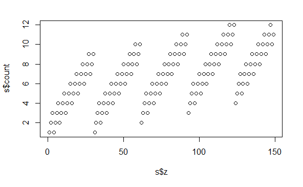

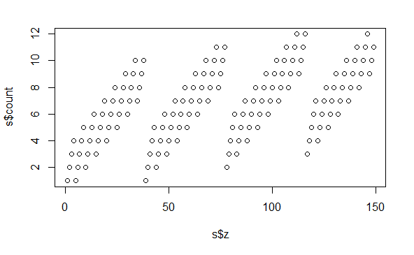

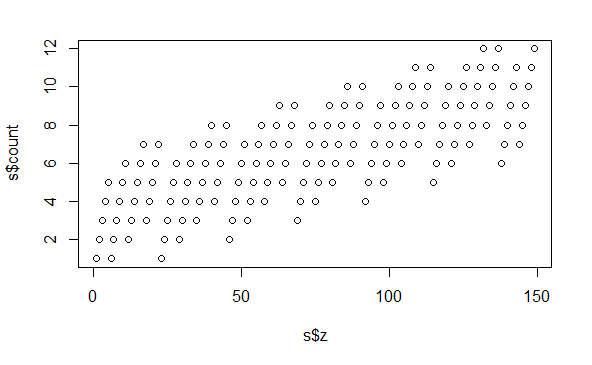

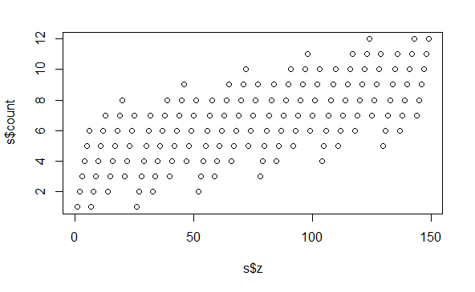

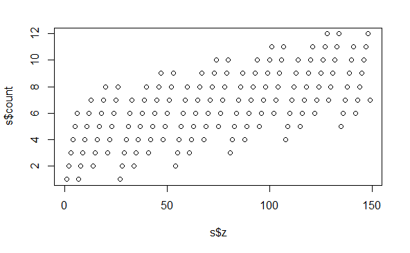

```r
mm <- mbest[mbest$nmax==3,]
for (i in seq(nrow(mm))) {
  s=coinz2(mm[i,'x'],mm[i,'y'])
  plot(s$z,s$count)
}
```

Which prices are the hardest to reach?

```r
print('Prices requiring most coins:')
```

```
[1] "Prices requiring most coins:"
```

```r
for (i in seq(nrow(mm))) {
  s <- coinz2(mm[i,'x'],mm[i,'y'])
  z <- s$z[s$count==12]
  print(c("Coin Values:",1,mm[i,'x'],mm[i,'y']))
  print(z)
}
```

```
[1] "Coin Values:" "1"            "4"            "31"
[1] 120 123 147
[1] "Coin Values:" "1"            "5"            "39"
[1] 112 116 146
[1] "Coin Values:" "1"            "6"            "23"
[1] 132 137 149
[1] "Coin Values:" "1"            "7"            "26"
[1] 124 143 149
[1] "Coin Values:" "1"            "7"            "27"
[1] 128 134 148
```

# Problem 2

From the original author:

```
For the second question, one unit is necessarily 1 (!) and there is
just an extra loop to the above, which returns M=8, with other units
taking several possible values:

[1] 40 11  3
[1] 41 11  3
[1] 55 15  4
[1] 56 15  4
```

Similar to the code above (using the non-optimal algorithm) we can make the nested loops and find the *optimal* combinations:

```r
# From above with three coins
# Note: we know this isn't optimal - but want to reproduce
# the results as presented in the Web posting.
coins <- function(w,x,y) {
  # We require 1<w<x<y
  s <- c(w,x,y)
  s <- sort(s)
  w=s[1]; x=s[2]; y=s[3]
  z=1:149
  ny <- z %/% y
  nx <- (z%%y) %/% x
  nw <- ((z%%y) %% x) %/% w
  no <- z-ny*y-nx*x-nw*w
  return(max(no+nw+nx+ny))
}
mbest=999
mworst=0
for (w in 2:147) {
  for (x in w:148) {
    for (y in x:149) {
      m=coins(w,x,y)
      if (m<mbest) { mbest = m }
      if (m>mworst) { mworst = m }
    }
  }
}
c(mbest,mworst)
```

```
[1]   8 146
```

Let’s find the coin combinations that yield the optimal result:

```r
moptimal=c()
for (w in 2:147) {
  for (x in w:148) {
    for (y in x:149) {
      m=coins(w,x,y)
      if (m==mbest) {
        moptimal=rbind(moptimal,c(w,x,y))
      }
    }
  }
}
moptimal=data.frame(moptimal)
names(moptimal)=c('w','x','y')
moptimal
```

| w | x | y |
| --- | --- | --- |
| 3 | 11 | 40 |
| 3 | 11 | 41 |
| 4 | 15 | 55 |
| 4 | 15 | 56 |

The author adds:

A quick search revealed that this problem (or a variant) is solved in many places, from stackexchange (for an average-why average?, as it does not make sense when looking at real prices-number of coins, rather than maximal), to a paper by Shalit calling for the 18¢ coin, to Freakonomics, to Wikipedia, although this is about finding the minimum number of coins summing up to a given value, using fixed currency denominations (a knapsack problem). This Wikipedia page made me realise that my solution is not necessarily optimal, as I use the remainders from the larger denominations in my code, while there may be more efficient divisions. For instance, running the following dynamic programming code

```r
coz=function(x,y){
  minco=1:149
  if (x<y){ xx=x;x=y;y=xx}
  for (i in 2:149){
    if (i%%x==0)
      minco[i]=i%/%x
    if (i%%y==0)
      minco[i]=min(minco[i],i%/%y)
    for (j in 1:max(1,trunc((i+1)/2)))
          minco[i]=min(minco[i],minco[j]+minco[i-j])
      }
  return(max(minco))}
```

returns the lower value of M=11 (with x=7,y=23) in the first case and M=7 in the second one.

Test this out below:

```r
mbest=999
for (x in 2:148) {
  for (y in x:149) {
    m<-coz(x,y)
    if (m<mbest) { mbest=m }
  }
}
mbest
```

```
[1] 11
```

So this code is more efficient than the original strategy of removing the maximum number of maximum denomination coins. The first strategy resulted in a minimum of 12 coins, here we achieve the result with 11 coins.

```r
moptimal=c()
for (x in 2:148) {
  for (y in x:149) {
    m<-coz(x,y)
    if (m==mbest) { moptimal<-rbind(moptimal,c(x,y)) }
  }
}
moptimal<-data.frame(moptimal)
names(moptimal)<-c('x','y')
moptimal
```

| x | y |
| --- | --- |
| 7 | 23 |
| 8 | 26 |
| 8 | 27 |
| 8 | 34 |
| 9 | 20 |
| 9 | 23 |
| 9 | 30 |
| 9 | 31 |
| 9 | 32 |
| 9 | 39 |

[output cut: 18 more lines]

There are 28 combinations that have an optimal coverage.

- How do we prove this works?
- If the price is an exact multiple of the largest denomination coin then the min coin count is the number of these coins
- If the price is an exact multiple of the second largest coin then the min coin count might be the number of these coins
- Find the smallest number of coins based on the sum of each pair of prices that sum up to the target price.

Here is a commented version of the code with storage of the actual coin combination that creates each total.

```r
# Determine the minimum number of coins required to achieve any
# amount in the range [1,149].  The coins are defined to have the
# following denominations:
#
#    1 < y < x
#
# The return value is a data frame consisting of the following
# columns:
#
#    index = total value
#    minco = minimum number of coins required
#
#    One combination of minco coins with the correct total
#    is represented by the final three columns
#
#    no = number of coins with value = 1
#    ny = number of coins with value = y
#    nx = number of coins with value = x
#
# Note that there is no guarantee that the no,ny,nx combination
# is unique.  The only guarantee is that minco gives the smallest
# number of coins.
coz2=function(x,y) {
  minco=1:149
  no=1:149
  nx=rep(0,149)
  ny=rep(0,149)
  no[1]=1
  if (x<y){ xx=x;x=y;y=xx }
  for (i in 2:149) {
    if (i%%x==0) {
      minco[i]=i%/%x
      nx[i]=i %/% x
      ny[i]=0
      no[i]=0
    }
    if (i%%y==0) {
      if ( (i%/%y)<minco[i] ) {
        minco[i] = i %/% y
        nx[i] = 0
        ny[i] = i %/% y
        no[i] = 0
      }
    }
    for (j in 1:max(1,trunc((i+1)/2))) {
      if ( (minco[j]+minco[i-j]) < minco[i]) {
        minco[i]=minco[j]+minco[i-j]
        nx[i]=nx[j]+nx[i-j]
        ny[i]=ny[j]+ny[i-j]
        no[i]=no[j]+no[i-j]
      }
    }
  }
  d=data.frame(minco=minco,no=no,ny=ny,nx=nx)
  return(d)
}
nmax=c()
for (i in seq(nrow(moptimal))) {
  d=coz2(moptimal[i,'x'],moptimal[i,'y'])
  nmax=c(nmax,sum(d$minco==max(d$minco)))
}
which(nmax==max(nmax))
```

```
[1] 18 25
```